# Reproducible Analysis of Politician Claims: An R Demo for R2CASS@ICWSM

## 3. Visualize Truth Rating Distribution

A bar chart provides a clear visual summary of the truth rating distribution. We’ll order the labels for better readability.

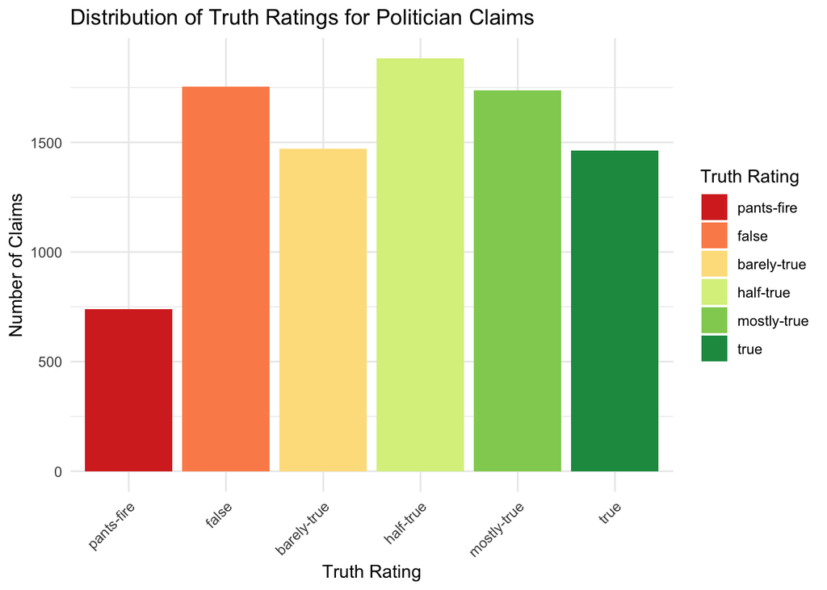

```r
# Define the order for labels to ensure consistent plotting
label_order <- c("pants-fire", "false", "barely-true", "half-true", "mostly-true", "true")

# Create a factor with the desired order
df$label_ordered <- factor(df$label, levels = label_order)

plot_truth_ratings <- df %>%
  ggplot(aes(x = label_ordered, fill = label_ordered)) +
  geom_bar() +
  labs(
    title = "Distribution of Truth Ratings for Politician Claims",
    x = "Truth Rating",
    y = "Number of Claims",
    fill = "Truth Rating"
  ) +
  theme_minimal() +
  theme(axis.text.x = element_text(angle = 45, hjust = 1)) +
  scale_fill_brewer(palette = "RdYlGn")

print(plot_truth_ratings)
```

```r
# Save the plot
ggsave("truth_ratings_distribution.png", plot_truth_ratings, path = ".", dpi = 300)
```

## 4. Analyze Distribution of Party Affiliation

Next, let’s look at the distribution of `party_affiliation` among the speakers.

### Distribution of Party Affiliations

```r
party_affiliation_counts <- df %>%
  count(party_affiliation) %>%
  arrange(desc(n)) %>%
  # Optional: Rename columns for better readability in the table
  rename(`Party Affiliation` = party_affiliation, `Number of Claims` = n)

party_affiliation_counts %>%
  kable(caption = "Count of Claims by Party Affiliation")
```

Count of Claims by Party Affiliation

| Party Affiliation | Number of Claims |
| --- | --- |
| republican | 3970 |
| democrat | 2953 |
| none | 1533 |
| organization | 193 |
| independent | 129 |
| newsmaker | 51 |
| activist | 35 |
| libertarian | 34 |
| columnist | 33 |
| journalist | 33 |
| talk-show-host | 22 |
| state-official | 19 |
| labor-leader | 10 |
| tea-party-member | 10 |
| business-leader | 9 |
| green | 2 |
| NA | 2 |
| Moderate | 1 |
| constitution-party | 1 |
| democratic-farmer-labor | 1 |
| education-official | 1 |
| government-body | 1 |
| liberal-party-canada | 1 |
| ocean-state-tea-party-action | 1 |

## 5. Visualize Party Affiliation Distribution

A bar chart to visualize the distribution of speaker party affiliations.

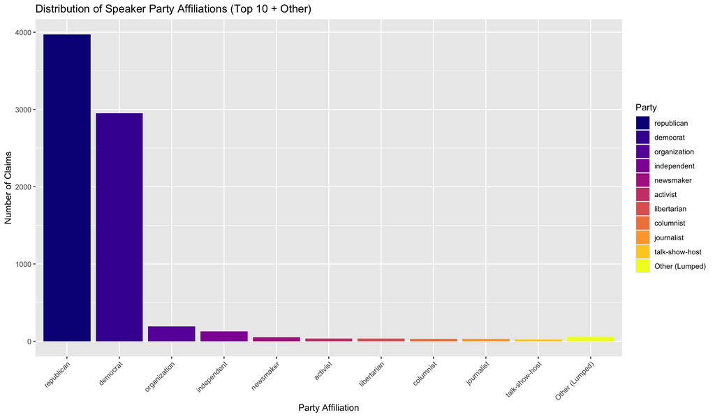

```r
# Ensure df exists and has data before proceeding with plotting
if (!is.null(df) && nrow(df) > 0) {
  plot_party_affiliation <- df %>%
    # Filter out NA and "none" for cleaner visualization
    filter(!is.na(party_affiliation), party_affiliation != "none") %>%
    mutate(
      # Group parties with small counts into 'Other' category
      # 'n = 10' will keep the 10 most frequent parties and lump the rest
      party_affiliation_grouped = fct_lump_n(fct_infreq(party_affiliation), n = 10, other_level = "Other (Lumped)")
    ) %>%
    ggplot(aes(x = party_affiliation_grouped, fill = party_affiliation_grouped)) + # Use the new grouped factor for x and fill
    geom_bar() +
    labs(
      title = "Distribution of Speaker Party Affiliations (Top 10 + Other)", # Updated title
      x = "Party Affiliation",
      y = "Number of Claims",
      fill = "Party"
    ) +
    theme(axis.text.x = element_text(angle = 45, hjust = 1)) +
    scale_fill_viridis_d(option = "plasma")

  print(plot_party_affiliation)

  # Save the plot
  ggsave("party_affiliation_distribution.png", plot_party_affiliation, path = ".", dpi = 300)
} else {
  cat("Party affiliation plot not generated: Data not available due to loading error.\n")
}
```

## 6. Relationship between Party Affiliation and Truth Ratings

Finally, let’s explore how truth ratings vary across different party affiliations using a stacked bar chart.

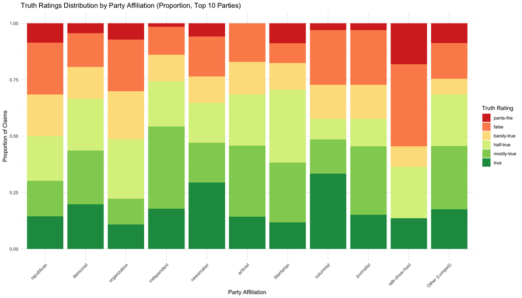

```r
if (!is.null(df) && nrow(df) > 0) {
  # Apply the same party grouping logic from Section 5 for consistency and readability
  # Also filter out NA and "none" for party affiliations as done previously
  plot_party_vs_truth <- df %>%
    filter(!is.na(party_affiliation), party_affiliation != "none") %>%
    mutate(
      party_affiliation_grouped = fct_lump_n(fct_infreq(party_affiliation), n = 10, other_level = "Other (Lumped)")
    ) %>%
    # Use the ordered truth labels (label_ordered) created in Section 3
    ggplot(aes(x = party_affiliation_grouped, fill = label_ordered)) +
    geom_bar(position = "fill") + # Use position="fill" for proportions (each bar sums to 100%)
    labs(
      title = "Truth Ratings Distribution by Party Affiliation (Proportion, Top 10 Parties)", # Updated title
      x = "Party Affiliation",
      y = "Proportion of Claims",
      fill = "Truth Rating"
    ) +
    theme_minimal() +
    theme(
      axis.text.x = element_text(angle = 45, hjust = 1),
      legend.position = "right", # Move legend outside the plot area to the right
      legend.box.just = "top" # Align legend to the top of its box
    ) +
    scale_fill_brewer(palette = "RdYlGn") # Red for false, Green for true (consistent with Section 3)

  print(plot_party_vs_truth)

  # Save the plot
  ggsave("party_vs_truth_stacked.png", plot_party_vs_truth, path = ".", dpi = 300)
} else {
  cat("Party affiliation vs. truth rating plot not generated: Data not available due to loading error.\n")
}
```

## Conclusion

Feel free to modify the code, add new analyses, or explore other aspects of the dataset!